# Inference on High Throughput Microscope Images

## Distributions of phenotypes

Percent colonization and count density are the two metrics for sorghum overall AMF colonization calculated from the filtered inference results.

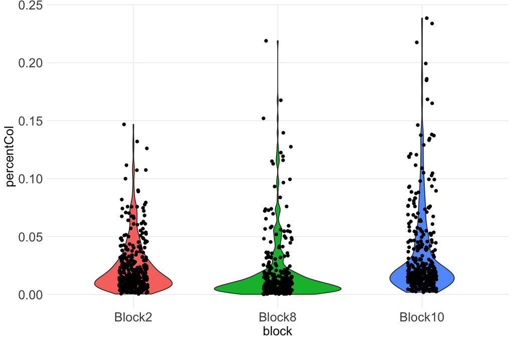

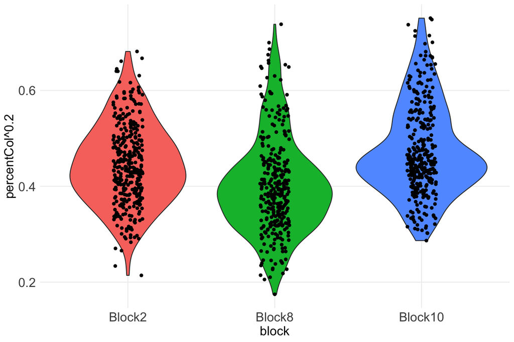

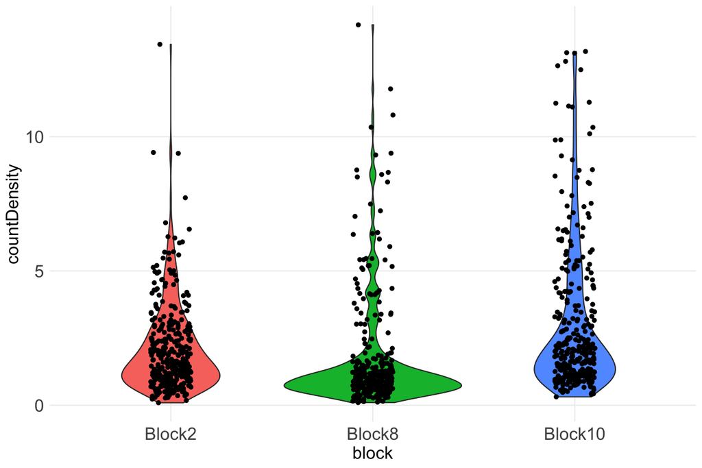

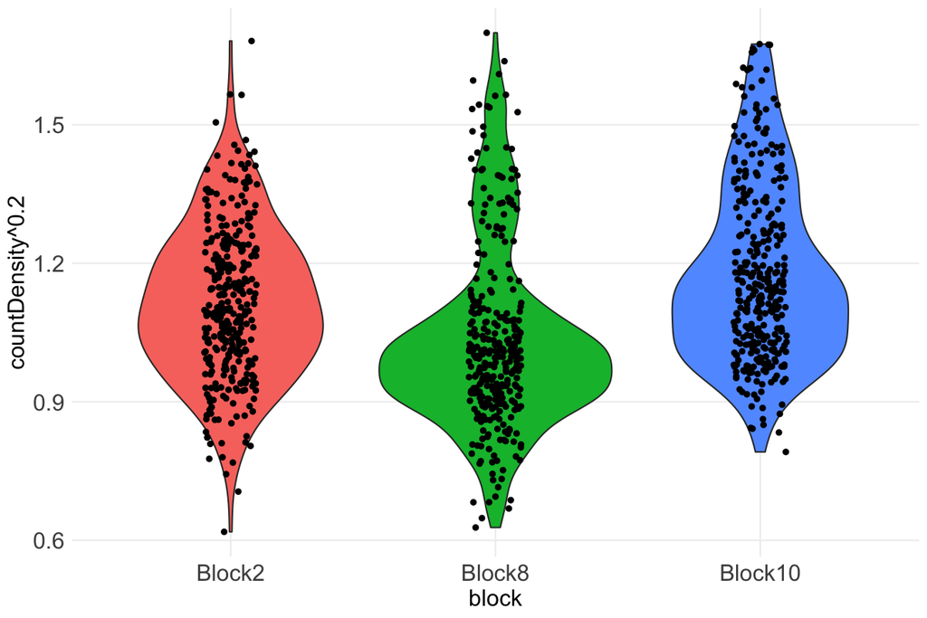

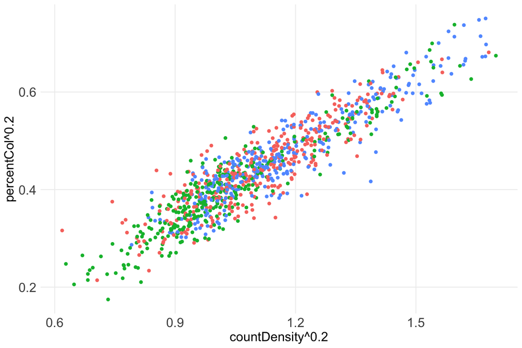

# Section 1.3: Block effect

Nancy mentioned that AMF colonization is highly variable depending on soil texture, nutrients and other environmental factors. I fitted random intercept models for block and accession effects. Chi-square test and Likelihood ratio test were used to test the significance of models.

## Percent colonization

Statistical tests result suggested that block to be a highly significant effect. Adding accession into the model did not significantly increase the amount of variance explained.

```r
pc.empty <- lmer(percentCol^0.2 ~ (1|accession), data = pheno)
pc.empty2 <- lmer(percentCol^0.2 ~ (1|block), data = pheno)
pc.blk <- lmer(percentCol^0.2 ~ (1|accession)+(1|block), data = pheno)

anova(pc.empty, pc.blk, test = "Chisq")
```

```
#> Data: pheno
#> Models:
#> pc.empty: percentCol^0.2 ~ (1 | accession)
#> pc.blk: percentCol^0.2 ~ (1 | accession) + (1 | block)
#>          npar     AIC     BIC logLik deviance  Chisq Df Pr(>Chisq)
#> pc.empty    3 -1789.2 -1774.5 897.59  -1795.2
#> pc.blk      4 -1870.8 -1851.3 939.43  -1878.8 83.674  1  < 2.2e-16 ***
#> ---
#> Signif. codes:  0 '***' 0.001 '**' 0.01 '*' 0.05 '.' 0.1 ' ' 1
```

```r
anova(pc.empty, pc.blk, test = "LRT") # AIC, BIC, deviance
```

```
#> Data: pheno
#> Models:
#> pc.empty: percentCol^0.2 ~ (1 | accession)
#> pc.blk: percentCol^0.2 ~ (1 | accession) + (1 | block)
#>          npar     AIC     BIC logLik deviance  Chisq Df Pr(>Chisq)
#> pc.empty    3 -1789.2 -1774.5 897.59  -1795.2
#> pc.blk      4 -1870.8 -1851.3 939.43  -1878.8 83.674  1  < 2.2e-16 ***
#> ---
#> Signif. codes:  0 '***' 0.001 '**' 0.01 '*' 0.05 '.' 0.1 ' ' 1
```

```r
confint(pc.blk)
```

```
#>                  2.5 %     97.5 %
#> .sig01      0.00000000 0.02509491
#> .sig02      0.01507561 0.08843321
#> .sigma      0.08818882 0.09752401
#> (Intercept) 0.39201644 0.48871984
```

```r
anova(pc.empty2, pc.blk, test = "Chisq")
```

```
#> Data: pheno
#> Models:
#> pc.empty2: percentCol^0.2 ~ (1 | block)
#> pc.blk: percentCol^0.2 ~ (1 | accession) + (1 | block)
#>           npar     AIC     BIC logLik deviance  Chisq Df Pr(>Chisq)
#> pc.empty2    3 -1872.8 -1858.1 939.41  -1878.8
#> pc.blk       4 -1870.8 -1851.3 939.43  -1878.8 0.0302  1      0.862
```

```r
anova(pc.empty2, pc.blk, test = "LRT") # AIC, BIC, deviance
```

```
#> Data: pheno
#> Models:
#> pc.empty2: percentCol^0.2 ~ (1 | block)
#> pc.blk: percentCol^0.2 ~ (1 | accession) + (1 | block)
#>           npar     AIC     BIC logLik deviance  Chisq Df Pr(>Chisq)
#> pc.empty2    3 -1872.8 -1858.1 939.41  -1878.8
#> pc.blk       4 -1870.8 -1851.3 939.43  -1878.8 0.0302  1      0.862
```

## Count density

Statistical tests result suggested that block to be a highly significant effect. Adding accession into the model did not significantly increase the amount of variance explained.

```r
cd.empty <- lmer(countDensity^0.2 ~ (1|accession), data = pheno)
cd.empty2 <- lmer(countDensity^0.2 ~ (1|block), data = pheno)
cd.blk <- lmer(countDensity^0.2 ~ (1|accession)+(1|block), data = pheno)
summary(cd.blk)
```

```
#> Linear mixed model fit by REML. t-tests use Satterthwaite's method [
#> lmerModLmerTest]
#> Formula: countDensity^0.2 ~ (1 | accession) + (1 | block)
#>    Data: pheno
#>
#> REML criterion at convergence: -518.6
#>
#> Scaled residuals:
#>     Min      1Q  Median      3Q     Max
#> -2.5964 -0.6851 -0.1442  0.5237  3.5294
#>
#> Random effects:
#>  Groups    Name        Variance Std.Dev.
#>  accession (Intercept) 0.001066 0.03265
#>  block     (Intercept) 0.005145 0.07173
#>  Residual              0.033129 0.18201
#> Number of obs: 991, groups:  accession, 336; block, 3
#>
#> Fixed effects:
#>             Estimate Std. Error      df t value Pr(>|t|)
#> (Intercept)  1.10791    0.04185 2.00662   26.47   0.0014 **
#> ---
#> Signif. codes:  0 '***' 0.001 '**' 0.01 '*' 0.05 '.' 0.1 ' ' 1
```

```r
anova(cd.empty, cd.blk, test = "Chisq")
```

```
#> Data: pheno
#> Models:
#> cd.empty: countDensity^0.2 ~ (1 | accession)
#> cd.blk: countDensity^0.2 ~ (1 | accession) + (1 | block)
#>          npar     AIC     BIC logLik deviance  Chisq Df Pr(>Chisq)
#> cd.empty    3 -433.59 -418.90 219.80  -439.59
#> cd.blk      4 -515.32 -495.72 261.66  -523.32 83.727  1  < 2.2e-16 ***
#> ---
#> Signif. codes:  0 '***' 0.001 '**' 0.01 '*' 0.05 '.' 0.1 ' ' 1
```

```r
anova(cd.empty, cd.blk, test = "LRT") # AIC, BIC, deviance
```

```
#> Data: pheno
#> Models:
#> cd.empty: countDensity^0.2 ~ (1 | accession)
#> cd.blk: countDensity^0.2 ~ (1 | accession) + (1 | block)
#>          npar     AIC     BIC logLik deviance  Chisq Df Pr(>Chisq)
#> cd.empty    3 -433.59 -418.90 219.80  -439.59
#> cd.blk      4 -515.32 -495.72 261.66  -523.32 83.727  1  < 2.2e-16 ***
#> ---
#> Signif. codes:  0 '***' 0.001 '**' 0.01 '*' 0.05 '.' 0.1 ' ' 1
```

```r
confint(cd.blk)
```

```
#>                  2.5 %     97.5 %
#> .sig01      0.00000000 0.05849552
#> .sig02      0.02976247 0.17443511
#> .sigma      0.17257545 0.19226090
#> (Intercept) 1.01249929 1.20330190
```

```r
anova(cd.empty2, cd.blk, test = "Chisq")
```

```
#> Data: pheno
#> Models:
#> cd.empty2: countDensity^0.2 ~ (1 | block)
#> cd.blk: countDensity^0.2 ~ (1 | accession) + (1 | block)
#>           npar     AIC     BIC logLik deviance  Chisq Df Pr(>Chisq)
#> cd.empty2    3 -516.40 -501.70 261.20  -522.40
#> cd.blk       4 -515.32 -495.72 261.66  -523.32 0.9206  1     0.3373
```

```r
anova(cd.empty2, cd.blk, test = "LRT") # AIC, BIC, deviance
```

```
#> Data: pheno
#> Models:
#> cd.empty2: countDensity^0.2 ~ (1 | block)
#> cd.blk: countDensity^0.2 ~ (1 | accession) + (1 | block)
#>           npar     AIC     BIC logLik deviance  Chisq Df Pr(>Chisq)
#> cd.empty2    3 -516.40 -501.70 261.20  -522.40
#> cd.blk       4 -515.32 -495.72 261.66  -523.32 0.9206  1     0.3373
```

## Block effect at fungal structure level

I didn’t fit any model here, but slight modification to the models above can be made to test the significance of the interactions between block and fungal structure frequency and size. Figures below indicated that differences in arbuscule size and hyphal frequency could be driving the block effect.

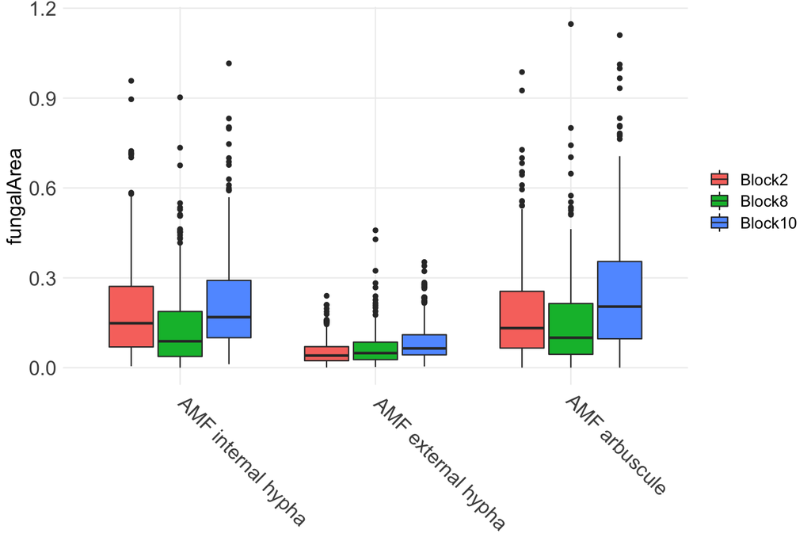

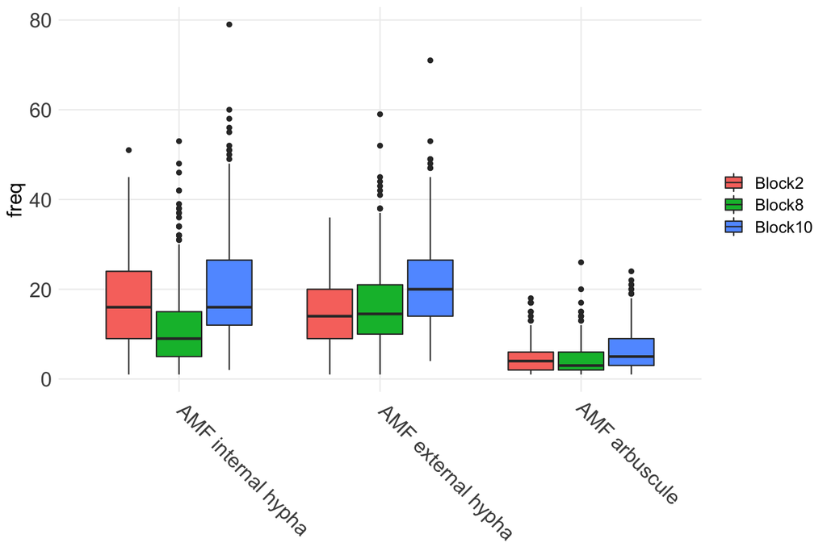